# Google Data Analytics Case Study

Aaron Tang

30/11/2021

# Cyclistic Bike Share

**Data Source**  
[Motivate International Inc](https://divvy-tripdata.s3.amazonaws.com/index.html)

### Install and Load tidyverse packages

```r
install.packages("tidyverse")
library(tidyverse)
```

# **Ask**

#### **Business Task**

Cyclistic finance analysts have determined that member riders are far more profitable than casual riders. The director of marketing, Lily Moreno, believes that to maximize the growth of the company, Cyclistic must increase the number of member riders. The objective is to answer how annual members and casual riders use Cyclistic bikes differently. Using this information, we then can determine a effective plan to convert Cyclistic existing casual riders to member riders.

#### **Rider Types**

**Casual** - Single-Ride Passes, Full-Day Passes  
**Member** - Annual Membership

#### **Key Stakeholders**

Director of Marketing (Lily Moreno), Cyclistic executive team, Marketing Analytics team, Finance Analysts

# **Prepare**

#### **Collect the Data**

The data was made available by [Motivate International Inc](https://divvy-tripdata.s3.amazonaws.com/index.html) under this [licence](https://www.divvybikes.com/data-license-agreement) and was assured by Google to be appropriate for answering the business question in this case study.

```r
q1_2020 <- read_csv(unz('./Divvy_Trips_2020_Q1.zip','Divvy_Trips_2020_Q1.csv'))
q4_2019 <- read_csv(unz('./Divvy_Trips_2019_Q4.zip','Divvy_Trips_2019_Q4.csv'))
q3_2019 <- read_csv(unz('./Divvy_Trips_2019_Q3.zip','Divvy_Trips_2019_Q3.csv'))
q2_2019 <- read_csv(unz('./Divvy_Trips_2019_Q2.zip','Divvy_Trips_2019_Q2.csv'))
```

#### **How the data is organized**

The original trip data was organized into yearly quarters.  
The 4 most recent yearly quarters data is used to have the most up to date data to analyze.

```r
str(q1_2020)
```

```
## spec_tbl_df [426,887 × 13] (S3: spec_tbl_df/tbl_df/tbl/data.frame)
##  $ ride_id           : chr [1:426887] "EACB19130B0CDA4A" "8FED874C809DC021" "789F3C21E472CA96" "C9A388DAC6ABF313" ...
##  $ rideable_type     : chr [1:426887] "docked_bike" "docked_bike" "docked_bike" "docked_bike" ...
##  $ started_at        : POSIXct[1:426887], format: "2020-01-21 20:06:59" "2020-01-30 14:22:39" ...
##  $ ended_at          : POSIXct[1:426887], format: "2020-01-21 20:14:30" "2020-01-30 14:26:22" ...
##  $ start_station_name: chr [1:426887] "Western Ave & Leland Ave" "Clark St & Montrose Ave" "Broadway & Belmont Ave" "Clark St & Randolph St" ...
##  $ start_station_id  : num [1:426887] 239 234 296 51 66 212 96 96 212 38 ...
##  $ end_station_name  : chr [1:426887] "Clark St & Leland Ave" "Southport Ave & Irving Park Rd" "Wilton Ave & Belmont Ave" "Fairbanks Ct & Grand Ave" ...
##  $ end_station_id    : num [1:426887] 326 318 117 24 212 96 212 212 96 100 ...
##  $ start_lat         : num [1:426887] 42 42 41.9 41.9 41.9 ...
##  $ start_lng         : num [1:426887] -87.7 -87.7 -87.6 -87.6 -87.6 ...
##  $ end_lat           : num [1:426887] 42 42 41.9 41.9 41.9 ...
##  $ end_lng           : num [1:426887] -87.7 -87.7 -87.7 -87.6 -87.6 ...
##  $ member_casual     : chr [1:426887] "member" "member" "member" "member" ...
##  - attr(*, "spec")=
##   .. cols(
##   ..   ride_id = col_character(),
##   ..   rideable_type = col_character(),
##   ..   started_at = col_datetime(format = ""),
##   ..   ended_at = col_datetime(format = ""),
##   ..   start_station_name = col_character(),
##   ..   start_station_id = col_double(),
##   ..   end_station_name = col_character(),
##   ..   end_station_id = col_double(),
##   ..   start_lat = col_double(),
##   ..   start_lng = col_double(),
##   ..   end_lat = col_double(),
##   ..   end_lng = col_double(),
##   ..   member_casual = col_character()
##   .. )
##  - attr(*, "problems")=<externalptr>
```

```r
str(q4_2019)
```

```
## spec_tbl_df [704,054 × 12] (S3: spec_tbl_df/tbl_df/tbl/data.frame)
##  $ trip_id          : num [1:704054] 25223640 25223641 25223642 25223643 25223644 ...
##  $ start_time       : POSIXct[1:704054], format: "2019-10-01 00:01:39" "2019-10-01 00:02:16" ...
##  $ end_time         : POSIXct[1:704054], format: "2019-10-01 00:17:20" "2019-10-01 00:06:34" ...
##  $ bikeid           : num [1:704054] 2215 6328 3003 3275 5294 ...
##  $ tripduration     : num [1:704054] 940 258 850 2350 1867 ...
##  $ from_station_id  : num [1:704054] 20 19 84 313 210 156 84 156 156 336 ...
##  $ from_station_name: chr [1:704054] "Sheffield Ave & Kingsbury St" "Throop (Loomis) St & Taylor St" "Milwaukee Ave & Grand Ave" "Lakeview Ave & Fullerton Pkwy" ...
##  $ to_station_id    : num [1:704054] 309 241 199 290 382 226 142 463 463 336 ...
##  $ to_station_name  : chr [1:704054] "Leavitt St & Armitage Ave" "Morgan St & Polk St" "Wabash Ave & Grand Ave" "Kedzie Ave & Palmer Ct" ...
##  $ usertype         : chr [1:704054] "Subscriber" "Subscriber" "Subscriber" "Subscriber" ...
##  $ gender           : chr [1:704054] "Male" "Male" "Female" "Male" ...
##  $ birthyear        : num [1:704054] 1987 1998 1991 1990 1987 ...
##  - attr(*, "spec")=
##   .. cols(
##   ..   trip_id = col_double(),
##   ..   start_time = col_datetime(format = ""),
##   ..   end_time = col_datetime(format = ""),
##   ..   bikeid = col_double(),
##   ..   tripduration = col_number(),
##   ..   from_station_id = col_double(),
##   ..   from_station_name = col_character(),
##   ..   to_station_id = col_double(),
##   ..   to_station_name = col_character(),
##   ..   usertype = col_character(),
##   ..   gender = col_character(),
##   ..   birthyear = col_double()
##   .. )
##  - attr(*, "problems")=<externalptr>
```

```r
str(q3_2019)
```

```
## spec_tbl_df [1,640,718 × 12] (S3: spec_tbl_df/tbl_df/tbl/data.frame)
##  $ trip_id          : num [1:1640718] 23479388 23479389 23479390 23479391 23479392 ...
##  $ start_time       : POSIXct[1:1640718], format: "2019-07-01 00:00:27" "2019-07-01 00:01:16" ...
##  $ end_time         : POSIXct[1:1640718], format: "2019-07-01 00:20:41" "2019-07-01 00:18:44" ...
##  $ bikeid           : num [1:1640718] 3591 5353 6180 5540 6014 ...
##  $ tripduration     : num [1:1640718] 1214 1048 1554 1503 1213 ...
##  $ from_station_id  : num [1:1640718] 117 381 313 313 168 300 168 313 43 43 ...
##  $ from_station_name: chr [1:1640718] "Wilton Ave & Belmont Ave" "Western Ave & Monroe St" "Lakeview Ave & Fullerton Pkwy" "Lakeview Ave & Fullerton Pkwy" ...
##  $ to_station_id    : num [1:1640718] 497 203 144 144 62 232 62 144 195 195 ...
##  $ to_station_name  : chr [1:1640718] "Kimball Ave & Belmont Ave" "Western Ave & 21st St" "Larrabee St & Webster Ave" "Larrabee St & Webster Ave" ...
##  $ usertype         : chr [1:1640718] "Subscriber" "Customer" "Customer" "Customer" ...
##  $ gender           : chr [1:1640718] "Male" NA NA NA ...
##  $ birthyear        : num [1:1640718] 1992 NA NA NA NA ...
##  - attr(*, "spec")=
##   .. cols(
##   ..   trip_id = col_double(),
##   ..   start_time = col_datetime(format = ""),
##   ..   end_time = col_datetime(format = ""),
##   ..   bikeid = col_double(),
##   ..   tripduration = col_number(),
##   ..   from_station_id = col_double(),
##   ..   from_station_name = col_character(),
##   ..   to_station_id = col_double(),
##   ..   to_station_name = col_character(),
##   ..   usertype = col_character(),
##   ..   gender = col_character(),
##   ..   birthyear = col_double()
##   .. )
##  - attr(*, "problems")=<externalptr>
```

```r
str(q2_2019)
```

```
## spec_tbl_df [1,108,163 × 12] (S3: spec_tbl_df/tbl_df/tbl/data.frame)
##  $ 01 - Rental Details Rental ID                   : num [1:1108163] 22178529 22178530 22178531 22178532 22178533 ...
##  $ 01 - Rental Details Local Start Time            : POSIXct[1:1108163], format: "2019-04-01 00:02:22" "2019-04-01 00:03:02" ...
##  $ 01 - Rental Details Local End Time              : POSIXct[1:1108163], format: "2019-04-01 00:09:48" "2019-04-01 00:20:30" ...
##  $ 01 - Rental Details Bike ID                     : num [1:1108163] 6251 6226 5649 4151 3270 ...
##  $ 01 - Rental Details Duration In Seconds Uncapped: num [1:1108163] 446 1048 252 357 1007 ...
##  $ 03 - Rental Start Station ID                    : num [1:1108163] 81 317 283 26 202 420 503 260 211 211 ...
##  $ 03 - Rental Start Station Name                  : chr [1:1108163] "Daley Center Plaza" "Wood St & Taylor St" "LaSalle St & Jackson Blvd" "McClurg Ct & Illinois St" ...
##  $ 02 - Rental End Station ID                      : num [1:1108163] 56 59 174 133 129 426 500 499 211 211 ...
##  $ 02 - Rental End Station Name                    : chr [1:1108163] "Desplaines St & Kinzie St" "Wabash Ave & Roosevelt Rd" "Canal St & Madison St" "Kingsbury St & Kinzie St" ...
##  $ User Type                                       : chr [1:1108163] "Subscriber" "Subscriber" "Subscriber" "Subscriber" ...
##  $ Member Gender                                   : chr [1:1108163] "Male" "Female" "Male" "Male" ...
##  $ 05 - Member Details Member Birthday Year        : num [1:1108163] 1975 1984 1990 1993 1992 ...
##  - attr(*, "spec")=
##   .. cols(
##   ..   `01 - Rental Details Rental ID` = col_double(),
##   ..   `01 - Rental Details Local Start Time` = col_datetime(format = ""),
##   ..   `01 - Rental Details Local End Time` = col_datetime(format = ""),
##   ..   `01 - Rental Details Bike ID` = col_double(),
##   ..   `01 - Rental Details Duration In Seconds Uncapped` = col_number(),
##   ..   `03 - Rental Start Station ID` = col_double(),
##   ..   `03 - Rental Start Station Name` = col_character(),
##   ..   `02 - Rental End Station ID` = col_double(),
##   ..   `02 - Rental End Station Name` = col_character(),
##   ..   `User Type` = col_character(),
##   ..   `Member Gender` = col_character(),
##   ..   `05 - Member Details Member Birthday Year` = col_double()
##   .. )
##  - attr(*, "problems")=<externalptr>
```

#### **Problems with the Data**

- Inconsistent column names, value nomenclature and types
- Missing columns in some data sets
- Contains unnecessary columns

# **Process**

#### **Follow Column naming convention from the most recent data set (q1_2020)**

```r
(q4_2019 <- rename(q4_2019
                   ,ride_id = trip_id
                   ,rideable_type = bikeid
                   ,started_at = start_time
                   ,ended_at = end_time
                   ,start_station_name = from_station_name
                   ,start_station_id = from_station_id
                   ,end_station_name = to_station_name
                   ,end_station_id = to_station_id
                   ,member_casual = usertype))

(q3_2019 <- rename(q3_2019
                   ,ride_id = trip_id
                   ,rideable_type = bikeid
                   ,started_at = start_time
                   ,ended_at = end_time
                   ,start_station_name = from_station_name
                   ,start_station_id = from_station_id
                   ,end_station_name = to_station_name
                   ,end_station_id = to_station_id
                   ,member_casual = usertype))

(q2_2019 <- rename(q2_2019
                   ,ride_id = "01 - Rental Details Rental ID"
                   ,rideable_type = "01 - Rental Details Bike ID"
                   ,started_at = "01 - Rental Details Local Start Time"
                   ,ended_at = "01 - Rental Details Local End Time"
                   ,start_station_name = "03 - Rental Start Station Name"
                   ,start_station_id = "03 - Rental Start Station ID"
                   ,end_station_name = "02 - Rental End Station Name"
                   ,end_station_id = "02 - Rental End Station ID"
                   ,member_casual = "User Type"))
```

#### **Convert all ride_id and rideable_type to character data type**

```r
q4_2019 <-  mutate(q4_2019, ride_id = as.character(ride_id)
                   ,rideable_type = as.character(rideable_type))
q3_2019 <-  mutate(q3_2019, ride_id = as.character(ride_id)
                   ,rideable_type = as.character(rideable_type))
q2_2019 <-  mutate(q2_2019, ride_id = as.character(ride_id)
                   ,rideable_type = as.character(rideable_type))
```

#### **Combine all quarters into one data frame**

```r
all_trips <- bind_rows(q2_2019, q3_2019, q4_2019, q1_2020)
```

#### **Remove unnecessary columns**

Columns related to gender, birth year, latitude and longitude will be removed as it won’t used in the analysis. “tripduration” and “01 - Rental Details Duration In Seconds Uncapped” will be removed and replaced by “ride_length”.

```r
all_trips <- all_trips %>%
  select(-c(start_lat, start_lng, end_lat, end_lng, birthyear, gender, "05 - Member Details Member Birthday Year", "Member Gender", "01 - Rental Details Duration In Seconds Uncapped", "tripduration"))
```

#### **Inspect “all_trips” for data cleaning**

```r
summary(all_trips)
```

```
##    ride_id            started_at                     ended_at
##  Length:3879822     Min.   :2019-04-01 00:02:22   Min.   :2019-04-01 00:09:48
##  Class :character   1st Qu.:2019-06-23 07:49:09   1st Qu.:2019-06-23 08:20:27
##  Mode  :character   Median :2019-08-14 17:43:38   Median :2019-08-14 18:02:04
##                     Mean   :2019-08-26 00:49:59   Mean   :2019-08-26 01:14:37
##                     3rd Qu.:2019-10-12 12:10:21   3rd Qu.:2019-10-12 12:36:16
##                     Max.   :2020-03-31 23:51:34   Max.   :2020-05-19 20:10:34
##
##  rideable_type      start_station_id start_station_name end_station_id
##  Length:3879822     Min.   :  1.0    Length:3879822     Min.   :  1.0
##  Class :character   1st Qu.: 77.0    Class :character   1st Qu.: 77.0
##  Mode  :character   Median :174.0    Mode  :character   Median :174.0
##                     Mean   :202.9                       Mean   :203.8
##                     3rd Qu.:291.0                       3rd Qu.:291.0
##                     Max.   :675.0                       Max.   :675.0
##                                                         NA's   :1
##  end_station_name   member_casual
##  Length:3879822     Length:3879822
##  Class :character   Class :character
##  Mode  :character   Mode  :character
##
##
##
##
```

```r
str(all_trips)
```

```
## tibble [3,879,822 × 9] (S3: tbl_df/tbl/data.frame)
##  $ ride_id           : chr [1:3879822] "22178529" "22178530" "22178531" "22178532" ...
##  $ started_at        : POSIXct[1:3879822], format: "2019-04-01 00:02:22" "2019-04-01 00:03:02" ...
##  $ ended_at          : POSIXct[1:3879822], format: "2019-04-01 00:09:48" "2019-04-01 00:20:30" ...
##  $ rideable_type     : chr [1:3879822] "6251" "6226" "5649" "4151" ...
##  $ start_station_id  : num [1:3879822] 81 317 283 26 202 420 503 260 211 211 ...
##  $ start_station_name: chr [1:3879822] "Daley Center Plaza" "Wood St & Taylor St" "LaSalle St & Jackson Blvd" "McClurg Ct & Illinois St" ...
##  $ end_station_id    : num [1:3879822] 56 59 174 133 129 426 500 499 211 211 ...
##  $ end_station_name  : chr [1:3879822] "Desplaines St & Kinzie St" "Wabash Ave & Roosevelt Rd" "Canal St & Madison St" "Kingsbury St & Kinzie St" ...
##  $ member_casual     : chr [1:3879822] "Subscriber" "Subscriber" "Subscriber" "Subscriber" ...
```

#### **Standardize “member_casual” column values to fit q1_2020 nomenclature**

Replace “Subscriber” with “member”  
Replace “Customer” with “casual”

```r
all_trips <-  all_trips %>%
  mutate(member_casual = recode(member_casual,"Subscriber" = "member", "Customer" = "casual"))
```

Ensure all values for member_casual were properly assigned

```r
table(all_trips$member_casual)
```

```
##
##  casual  member
##  905954 2973868
```

#### **Create columns for data, year, month and day of every trip start time**

```r
all_trips$date <- as.Date(all_trips$started_at) #The default format is yyyy-mm-dd
all_trips$month <- format(as.Date(all_trips$date), "%m")
all_trips$day <- format(as.Date(all_trips$date), "%d")
all_trips$year <- format(as.Date(all_trips$date), "%Y")
all_trips$day_name <- format(as.Date(all_trips$date), "%a")
all_trips$month_name <- format(as.Date(all_trips$date), "%b")


#Fix the order of the days
all_trips$day_name <- ordered(all_trips$day_name, levels=c("Sun", "Mon", "Tue", "Wed", "Thu", "Fri", "Sat"))

#Fix the order of the months
all_trips$month_name <- ordered(all_trips$month_name, levels=c("Jan", "Feb", "Mar", "Apr", "May", "Jun", "Jul", "Aug", "Sep", "Oct", "Nov", "Dec"))
```

#### **Add “ride_length column (in seconds)**

```r
all_trips$ride_length <- difftime(all_trips$ended_at,all_trips$started_at, units="secs")
```

#### **Convert “ride_length” type from difftime to numeric**

```r
is.numeric(all_trips$ride_length)
all_trips$ride_length <- as.numeric(all_trips$ride_length)
is.numeric(all_trips$ride_length)
```

#### **Inspect “ride_length”, “start_station_name” and “end_station_name”**

Check for “ride_length” that is less than or equal to zero.  
“ride_length” values less than or equal to zero are invalid and will be removed.

```r
range(all_trips$ride_length)
```

```
## [1]   -3382 9387024
```

Check for anomalies in start_station_name and end_station_name

```r
unique(sort(all_trips$start_station_name))
unique(sort(all_trips$end_station_name))
```

#### **Findings**

- Values in “ride_length” less than or equal to zero was found
- Found several station names in “start_station_name” and “end_station_name” that represented repairs, tests, or special events done by Cyclistic. For example, “DIVVY CASSETTE REPAIR MOBILE STATION”, “DIVVY Map Frame B/C Station” and more.
- Some station names include “(*)” and “(Temp)” at the end of the station names. At times, the station names are repeated but with “(*)” or “(Temp)” at the end of the station name. For example, “Sangamon St & Washington Blvd” and “Sangamon St & Washington Blvd (*)”

#### **Remove all instances where “start_station_name” or “end_station_name” contains a value that indicates repairs, tests or special events done by Cyclistic and “ride_length” values less than or equal to zero**

Create new Data Frame since data is being removed

```r
all_trips_v2 <- all_trips[!(all_trips$start_station_name == "HQ QR" | all_trips$end_station_name == "HQ QR"|
                              all_trips$start_station_name == "DIVVY CASSETTE REPAIR MOBILE STATION" | all_trips$end_station_name == "DIVVY CASSETTE REPAIR MOBILE STATION"|
                              all_trips$start_station_name == "DIVVY Map Frame B/C Station" | all_trips$end_station_name == "DIVVY Map Frame B/C Station"|
                              all_trips$start_station_name == "HUBBARD ST BIKE CHECKING (LBS-WH-TEST)" | all_trips$end_station_name == "HUBBARD ST BIKE CHECKING (LBS-WH-TEST)"|
                              all_trips$start_station_name == "LBS - BBB La Magie" | all_trips$end_station_name == "LBS - BBB La Magie"|
                              all_trips$start_station_name == "MTL-ECO5.1-01" | all_trips$end_station_name == "MTL-ECO5.1-01"|
                              all_trips$start_station_name == "Special Events" | all_trips$end_station_name == "Special Events"|
                              all_trips$ride_length<=0),]
```

#### **Check for missing values**

```r
sum(is.na(all_trips_v2))
```

```
## [1] 0
```

#### **Remove substrings ” (*)” and ” (Temp)” in all station names**

```r
all_trips_v2$start_station_name = gsub(" (*)","",all_trips_v2$start_station_name, fixed = TRUE)
all_trips_v2$start_station_name = gsub(" (Temp)","", all_trips_v2$start_station_name, fixed = TRUE)
all_trips_v2$end_station_name = gsub(" (*)","",all_trips_v2$end_station_name, fixed = TRUE)
all_trips_v2$end_station_name = gsub(" (Temp)","", all_trips_v2$end_station_name, fixed = TRUE)
```

# **Analyze**

#### **Compare Min, Max, Median, Mean**

```r
#Min
aggregate(ride_length ~ member_casual, data = all_trips_v2 ,FUN = min)
```

```
##   member_casual ride_length
## 1        casual           2
## 2        member           1
```

```r
#Max
aggregate(ride_length ~ member_casual, data = all_trips_v2 ,FUN = max)
```

```
##   member_casual ride_length
## 1        casual     9387024
## 2        member     6028602
```

```r
#Median
aggregate(ride_length ~ member_casual, data = all_trips_v2 ,FUN = median)
```

```
##   member_casual ride_length
## 1        casual        1546
## 2        member         589
```

```r
#Mean
aggregate(ride_length ~ member_casual, data = all_trips_v2 ,FUN = mean)
```

```
##   member_casual ride_length
## 1        casual    3344.004
## 2        member     832.834
```

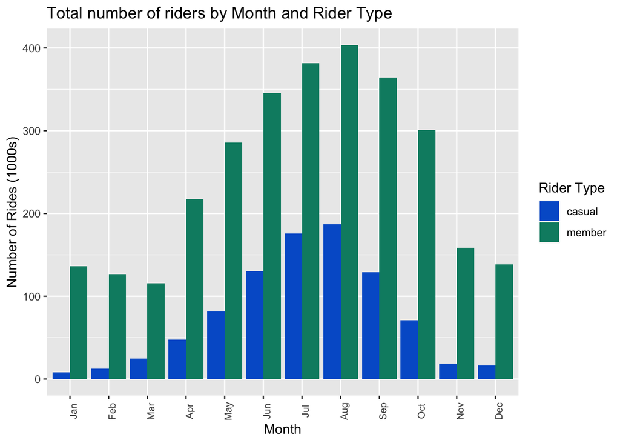

[figure not shown]

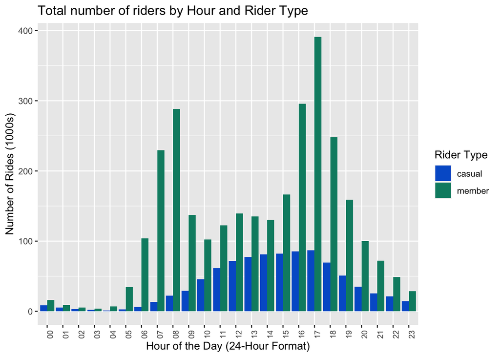

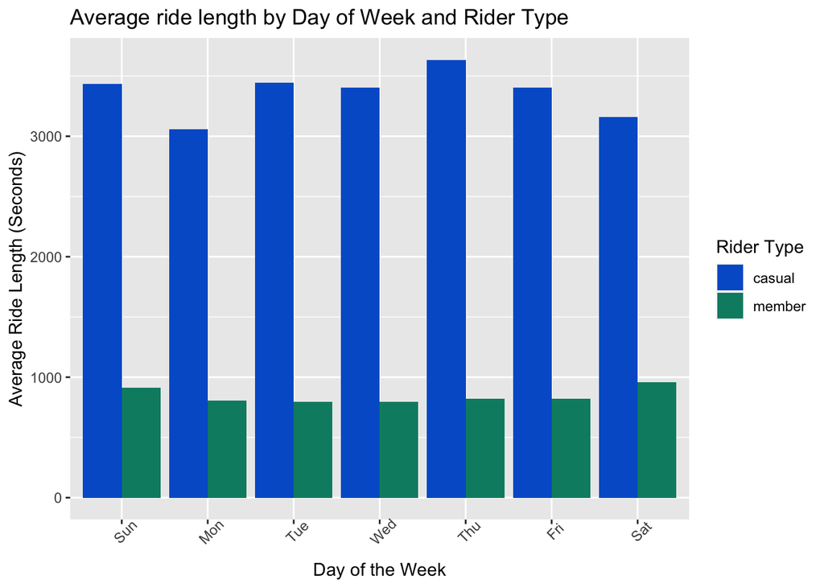

#### **Determine the Top 5 most popular stations for member riders (Most -> Least)**

#### **“Canal St & Adams St”, “Clinton St & Madison St”, “Clinton St & Washington Blvd”, “Columbus Dr & Randolph St”, “Franklin St & Monroe St”**

```
##
##          Canal St & Adams St      Clinton St & Madison St
##                        51946                        46190
## Clinton St & Washington Blvd    Columbus Dr & Randolph St
##                        43588                        31052
##      Franklin St & Monroe St
##                        30981
```

#### **Determine the Top 5 most popular stations for casual riders (Most -> Least)**

#### **“Streeter Dr & Grand Ave”, “Lake Shore Dr & Monroe St”, “Millennium Park”, “Michigan Ave & Oak St”, “Shedd Aquarium”**

```
##
##   Streeter Dr & Grand Ave Lake Shore Dr & Monroe St           Millennium Park
##                     53412                     39681                     21900
##     Michigan Ave & Oak St            Shedd Aquarium
##                     21629                     20780
```

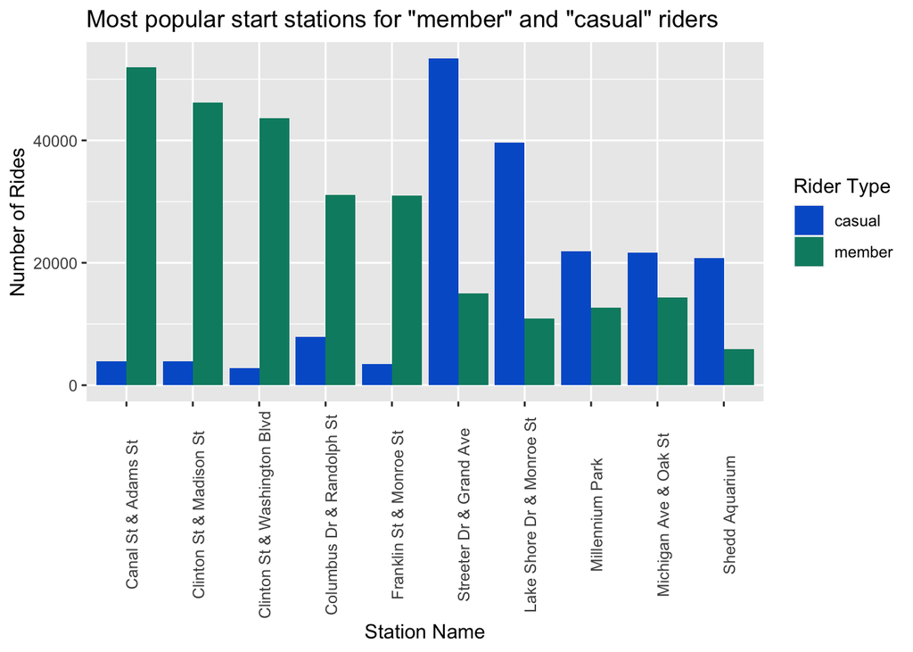

#### **Determine the Top 5 most end popular stations for member riders (Most -> Least)**

#### **Canal St & Adams St, Clinton St & Washington Blvd, Clinton St & Madison St, Daley Center Plaza, Kingsbury St & Kinzie St**

```r
sort(table(subset(all_trips_v2, member_casual=="member")$end_station_name), decreasing = TRUE)[1:5]
```

```
##
##          Canal St & Adams St Clinton St & Washington Blvd
##                        48839                        47628
##      Clinton St & Madison St           Daley Center Plaza
##                        44285                        30844
##     Kingsbury St & Kinzie St
##                        30404
```

#### **Determine the Top 5 most end popular stations for casual riders (Most -> Least)**

#### **“Streeter Dr & Grand Ave”, “Lake Shore Dr & Monroe St”, “Millennium Park”, “Michigan Ave & Oak St”, “Lake Shore & North Blvd”**

```r
sort(table(subset(all_trips_v2, member_casual=="casual")$end_station_name), decreasing = TRUE)[1:5]
```

```
##
##    Streeter Dr & Grand Ave  Lake Shore Dr & Monroe St
##                      67507                      31051
##            Millennium Park      Michigan Ave & Oak St
##                      25509                      23982
## Lake Shore Dr & North Blvd
##                      23477
```

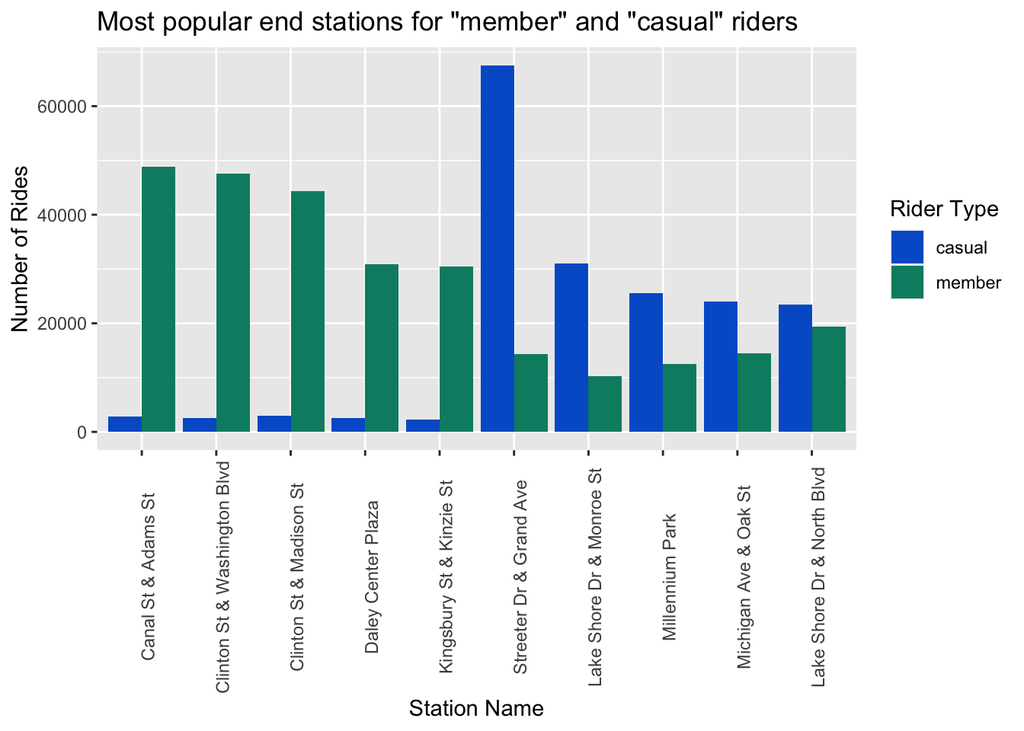

# **Act**

#### **Key Findings**

**2. Warmer months have the highest ridership for both “casual” and “member” riders**  
- June, July, August and September

**3. “casual” ridership peak on the weekend and “member” ridership peak on the weekdays**

**4. “member” riders ride lengths are much shorter than “casual” riders**  
- “casual” average ride length is 3344.004 seconds (55 minutes and 44.004 seconds)  
- “member” average ride length is 832.834 seconds (13 minutes and 52.834 seconds)

**5. No commonalities between most popular starting/end locations for “member” and “casual” riders**

#### **Recommendations**

**1. New membership (Weekend Membership Special)**  
- Unlimited rides  
- Weekdays 30 Minutes Max rides  
- Weekdays 90 Minutes Max rides

**2. Advertise in most popular start/end stations for “casual” riders**  
- “Streeter Dr & Grand Ave”, “Lake Shore Dr & Monroe St” and “Millennium Park”

**3. Advertise on the weekends during the warmer months (June - September)**  
- Peak “casual” ridership during those days and months  
- “casual” ridership drops drastically during colder months

**5. Collaborate with recreational places/events to offer special ticket prices or discounts on foods for new “member” riders** - Select recreational places/events that are in close proximity to the most popular start/end stations for “casual” riders